# Reproducible Research: Project 1

Andrew Engebretson

July 7, 2016

## Introduction

It is now possible to collect a large amount of data about personal movement using activity monitoring devices such as a Fitbit, Nike Fuelband, or Jawbone Up. These type of devices are part of the “quantified self” movement - a group of enthusiasts who take measurements about themselves regularly to improve their health, to find patterns in their behavior, or because they are tech geeks. But these data remain under-utilized both because the raw data are hard to obtain and there is a lack of statistical methods and software for processing and interpreting the data.

This assignment makes use of data from a personal activity monitoring device. This device collects data at 5 minute intervals through out the day. The data consists of two months of data from an anonymous individual collected during the months of October and November, 2012 and include the number of steps taken in 5 minute intervals each day.

## Loading and preprocessing the data

### Data

Data Source: https://d396qusza40orc.cloudfront.net/repdata%2Fdata%2Factivity.zip

The variables included in this dataset are:

- steps: Number of steps taking in a 5-minute interval (missing values are coded as NA)
- date: The date on which the measurement was taken in YYYY-MM-DD format
- interval: Identifier for the 5-minute interval in which measurement was taken

### Load the data

```r
if(!file.exists('activity.csv')){
    unzip('activity.zip')
}
activityData <- read.csv('activity.csv')
```

## What is mean total number of steps taken per day?

**1. . Calculate the total number of steps taken per day.**

```r
totalSteps <- tapply(activityData$steps, activityData$date, sum, na.rm = TRUE)
```

**2. Make a histogram of the total number of steps taken each day.**

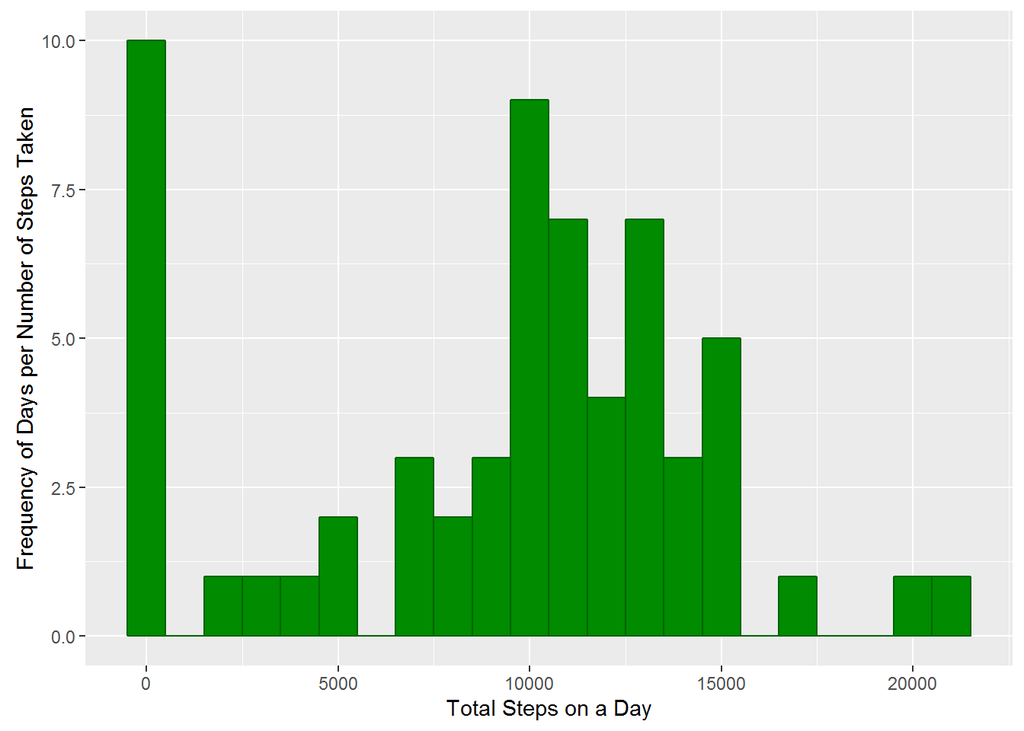

```r
library(ggplot2)
qplot(totalSteps, xlab = 'Total Steps on a Day', ylab = 'Frequency of Days per Number of Steps Taken', binwidth = 1000, fill = I("green4"), col = I("darkgreen"))
```

**3. Calculate and report the mean and median of the total number of steps taken per day.**

Mean Steps

```r
meanSteps <- mean(totalSteps)
meanSteps
```

```
## [1] 9354.23
```

Median Steps

```r
medianSteps <- median(totalSteps)
medianSteps
```

```
## [1] 10395
```

## What is the average daily activity pattern?

**1. Make a time series plot (i.e. type = “l”) of the 5-minute interval (x-axis) and the average number of steps taken, averaged across all days (y-axis)**

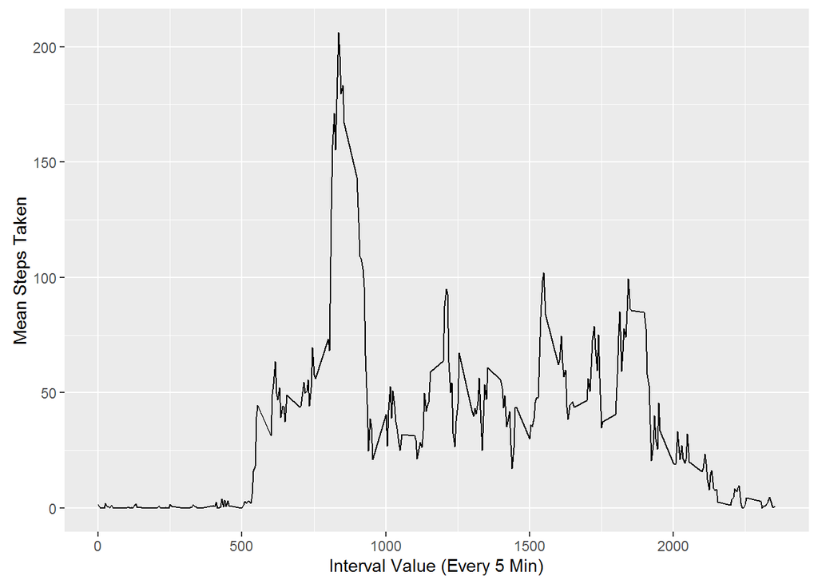

```r
averageSteps <- aggregate(x=list(meanSteps=activityData$steps), by=list(interval=activityData$interval), FUN=mean, na.rm=TRUE)
ggplot(data=averageSteps, aes(x=interval, y=meanSteps)) +
    geom_line() + xlab("Interval Value (Every 5 Min)") + ylab("Mean Steps Taken")
```

**2. Which 5-minute interval, on average across all the days in the dataset, contains the maximum number of steps?**

```r
maxStepsRowNum <- which.max(averageSteps$meanSteps)
intervalMaxSteps <- averageSteps[maxStepsRowNum,'interval']
intervalMaxSteps
```

```
## [1] 835
```

## Inputing missing values

**1. Calculate and report the total number of missing values in the dataset (i.e. the total number of rows with NAs).**

```r
nullSteps <- is.na(activityData$steps)
table(nullSteps)
```

```
## nullSteps
## FALSE  TRUE
## 15264  2304
```

**2. Devise a strategy for filling in all of the missing values in the dataset. Create a new dataset that is equal to the original dataset but with the missing data filled in.**

```r
activityData2 <- activityData
for (ndx in 1:nrow(activityData2))
{
    if (is.na(activityData2[ndx,"steps"]) == TRUE)
    {
        activityData2[ndx,"steps"] <- round(averageSteps[which(averageSteps$interval == activityData2[ndx,"interval"]),"meanSteps"])
    }
}
head(activityData)
```

```
##   steps       date interval
## 1    NA 2012-10-01        0
## 2    NA 2012-10-01        5
## 3    NA 2012-10-01       10
## 4    NA 2012-10-01       15
## 5    NA 2012-10-01       20
## 6    NA 2012-10-01       25
```

```r
head(activityData2)
```

```
##   steps       date interval
## 1     2 2012-10-01        0
## 2     0 2012-10-01        5
## 3     0 2012-10-01       10
## 4     0 2012-10-01       15
## 5     0 2012-10-01       20
## 6     2 2012-10-01       25
```

**3. Make a histogram of the total number of steps taken each day and Calculate and report the mean and median total number of steps taken per day. Do these values differ from the estimates from the first part of the assignment? What is the impact of imputing missing data on the estimates of the total daily number of steps?**

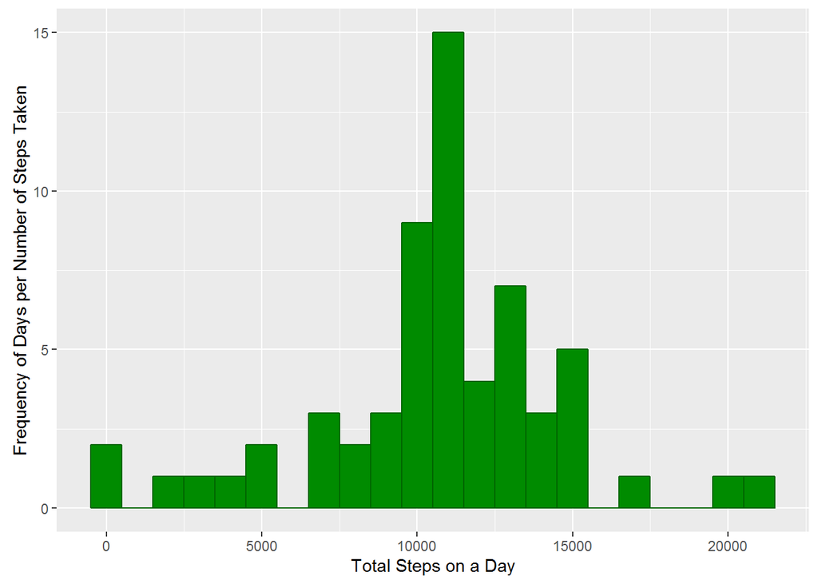

```r
totalSteps2 <- tapply(activityData2$steps, activityData2$date, sum, na.rm = TRUE)
qplot(totalSteps2, xlab = 'Total Steps on a Day', ylab = 'Frequency of Days per Number of Steps Taken', binwidth = 1000, fill = I("green4"), col = I("darkgreen"))
```

Mean Steps

```r
meanSteps2 <- mean(totalSteps2)
meanSteps2
```

```
## [1] 10765.64
```

Median Steps

```r
medianSteps2 <- median(totalSteps2)
medianSteps2
```

```
## [1] 10762
```

## Are there differences in activity patterns between weekdays and weekends?

**1. Create a new factor variable in the dataset with two levels - “weekday” and “weekend” indicating whether a given date is a weekday or weekend day.**

```r
weekends <- c("Saturday", "Sunday")
activityData2$dateType = as.factor(ifelse(is.element(weekdays(as.Date(activityData2$date)),weekends), "Weekend", "Weekday"))
```

**2. Make a panel plot containing a time series plot (i.e. type = “l”) of the 5-minute interval (x-axis) and the average number of steps taken, averaged across all weekday days or weekend days (y-axis).**

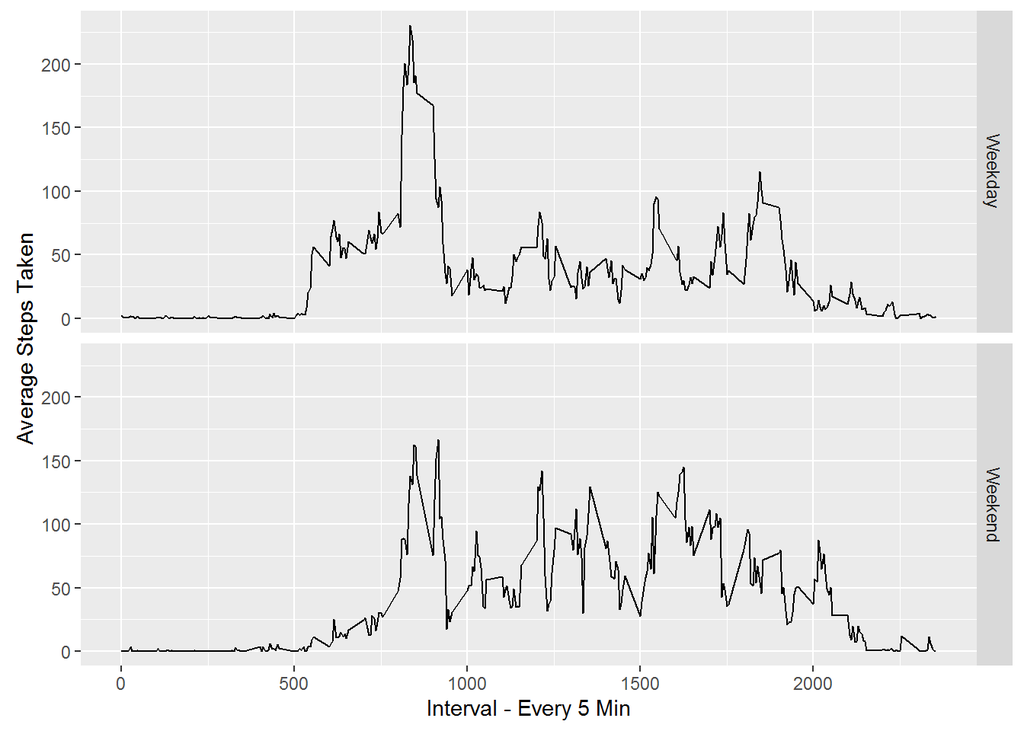

```r
averageSteps2 <- aggregate(steps ~ interval + dateType, data=activityData2, mean)
ggplot(averageSteps2, aes(interval, steps)) +
    geom_line() +
    facet_grid(dateType ~ .) +
    xlab("Interval - Every 5 Min")  +
    ylab("Average Steps Taken")
```